# Report Exercise 8: Regression

Noémie Wellinger

2023-06-08

# 1 Introduction

When fitting linear regression models, it is important to choose the best predictors to achieve good model performance. This process of finding the “best” model is referred to as “model selection”. As it would be very time and resource consuming to try each combination of available predictors, there exists a “greedy” approach to this problem: the stepwise forward regression. It starts with an empty model (just an intercept) and adds one predictor at a time to the model formula - as long as the added predictor increases model performance. The aim of this exercises is to implement a stepwise forward regression, to understand the functionality and asses which predictors are most important for a multivariate regression model predicting GPP.

# 2 Methods and Results

```r
library(tidyverse)
library(ggplot2)
```

## 2.1 Read and preprocess data

```r
hh_fluxes <- readr::read_csv("https://raw.githubusercontent.com/geco-bern/agds/main/data/df_for_stepwise_regression.csv")
```

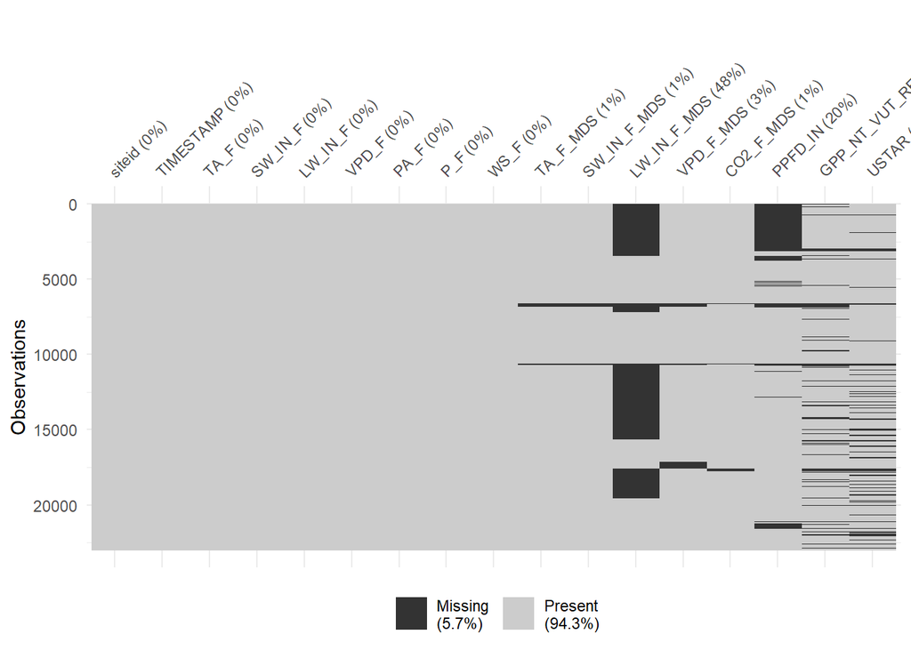

Figure 1: Missing values in the whole dataset

```r
plot_na <- visdat::vis_miss(
  hh_fluxes,
  cluster = FALSE,
  warn_large_data = FALSE
  )
plot_na
```

The variable LW_IN_F_MDS contains a lot of missing values. As noted in the AGDS script in chapter 9.2.7.2, longwave radiation is not a strong factor for GPP and there is another non-gapfilled version of the same variable. Therefore we can drop the variable for all the subsequent models.

```r
hh_fluxes <- hh_fluxes |>
  subset(select = -LW_IN_F_MDS)
```

## 2.2 Evaluation of all bivariate models (single predictor)

```r
#initialize the predictors
preds_single <- hh_fluxes |>
  subset(select = -c(siteid, TIMESTAMP, GPP_NT_VUT_REF)) |> # all predictors
  drop_na()

#store the predictors in a list of numeric vectors, the variable
remaining_candidates <- as.list(preds_single)
#initialize df for r-squared values
r_squared <- data.frame(pred = "init", rsq_values = 0)

# loop over the predictors
for (pred_candidate in names(remaining_candidates)){

  #specify the model, creating the formula dynamically
  lm <- lm(formula = as.formula(paste("GPP_NT_VUT_REF ~", paste(pred_candidate, collapse = "+"))),
           data = hh_fluxes)

  #extract R-squared values of all predictors
  r_squared <- r_squared |> add_row(pred = pred_candidate,
                       rsq_values = summary(lm)$r.squared)
}

#determine max R-squared and corresponding variable name
max_rsq_pred <- r_squared$pred[which.max(r_squared$rsq_values)]
print(paste("Highest r-squared: ", max_rsq_pred, max(r_squared$rsq_values)))
```

```
## [1] "Highest r-squared:  PPFD_IN 0.452070231265466"
```

```r
#store the model
linmod_single <- lm(formula = as.formula(paste("GPP_NT_VUT_REF ~", max_rsq_pred)),
           data = hh_fluxes)
```

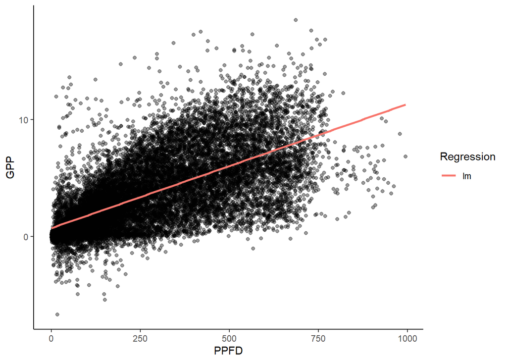

Figure 2: Best bivariate linear regression model for GPP

## 2.3 Stepwise regression

The stepwise regression works as follows (steps from the AGDS script, section 8.2.3.1):

1. Set the number of predictors to be considered to p=1
2. Fit all regression models with p predictors and compute their R2
3. Select the model with p predictors that achieves the highest R2 (best fitting model) and compute its AIC.
4. Increment to p+1. Fit all regression models with p+1 predictors and compute their R2. Select the best fitting model and compute its AIC.
5. If the AIC of the model with p+1 predictors is poorer than the AIC of the model with p predictors, retain the model with p predictors and quit. You have found the (presumably) optimal model. Otherwise, continue with with step 4.

The stepwise regression function is implemented in the R file `stepwise_regression.R`.

Let’s try different sets of predictors

```r
preds_stepwise1 <- hh_fluxes |>
  subset(select = -c(siteid, TIMESTAMP, GPP_NT_VUT_REF)) |>
  drop_na()

#remove all the gapfilled data to avoid strongly correlated predictors
preds_stepwise2 <- hh_fluxes |>
  subset(select = -c(siteid, TIMESTAMP, GPP_NT_VUT_REF, TA_F_MDS, SW_IN_F_MDS, VPD_F_MDS)) |>
  drop_na()

#take out PPFD_since it was the most important predictor for the single model
preds_stepwise3 <- hh_fluxes |>
  subset(select = -c(siteid, TIMESTAMP, GPP_NT_VUT_REF, TA_F_MDS, SW_IN_F_MDS, VPD_F_MDS, PPFD_IN)) |>
  drop_na()
```

Calculate stepwise linear regression models using the three predictors sets defined above

```r
linmod1 <- stepwise_regression(preds_stepwise1, hh_fluxes, "GPP_NT_VUT_REF")
```

```
## [1] "GPP_NT_VUT_REF  ~ PPFD_IN+LW_IN_F+VPD_F+TA_F_MDS+SW_IN_F+P_F+WS_F+CO2_F_MDS+PA_F+TA_F"
##
## Call:
## lm(formula = as.formula(lm_formula), data = data)
##
## Coefficients:
## (Intercept)      PPFD_IN      LW_IN_F        VPD_F     TA_F_MDS      SW_IN_F
##   -1.589166     0.006722     0.015243    -0.388585     0.103532     0.012781
##         P_F         WS_F    CO2_F_MDS         PA_F
##   -0.023391    -0.137464    -0.006434     0.007716
```

```r
linmod2 <- stepwise_regression(preds_stepwise2, hh_fluxes, "GPP_NT_VUT_REF")
```

```
## [1] "GPP_NT_VUT_REF  ~ PPFD_IN+LW_IN_F+VPD_F+TA_F+SW_IN_F+P_F+WS_F+CO2_F_MDS+PA_F+USTAR"
##
## Call:
## lm(formula = as.formula(lm_formula), data = data)
##
## Coefficients:
## (Intercept)      PPFD_IN      LW_IN_F        VPD_F         TA_F      SW_IN_F
##   -1.597694     0.006726     0.015257    -0.388399     0.103319     0.012777
##         P_F         WS_F    CO2_F_MDS         PA_F
##   -0.023382    -0.137481    -0.006435     0.007774
```

```r
linmod3 <- stepwise_regression(preds_stepwise3, hh_fluxes, "GPP_NT_VUT_REF")
```

```
## [1] "GPP_NT_VUT_REF  ~ SW_IN_F+LW_IN_F+VPD_F+TA_F+P_F+WS_F+CO2_F_MDS+USTAR+PA_F"
##
## Call:
## lm(formula = as.formula(lm_formula), data = data)
##
## Coefficients:
## (Intercept)      SW_IN_F      LW_IN_F        VPD_F         TA_F          P_F
##   -0.955710     0.023146     0.014289    -0.385395     0.147300    -0.027417
##        WS_F    CO2_F_MDS        USTAR
##   -0.402868    -0.005906     2.123671
```

# 3 Discussion

First, let’s look at the metrics of the four models that were fitted.

Table 1: Metrics of the different linear models

| type | mse | rmse | R2 | R2_adj | AIC | AIC_adj | BIC |
| --- | --- | --- | --- | --- | --- | --- | --- |
| 1. Linear model single predictor | 5.808 | 2.410 | 0.452 | 0.452 | 29689.54 | 29689.54 | 77601.07 |
| 2. Linear model stepwise, all predictors | 4.259 | 2.064 | 0.598 | 0.598 | 24469.28 | 24469.30 | 72442.69 |
| 3. Linear model stepwise, gapfilled removed | 4.259 | 2.064 | 0.598 | 0.598 | 24472.13 | 24472.15 | 72445.54 |
| 4. Linear model stepwise, gapfilled and PPFT removed | 4.109 | 2.027 | 0.596 | 0.596 | 27452.13 | 27452.14 | 82624.57 |

To better understand the linear models, here are descriptions of the variables in the FLUXNET dataset. More info on: https://fluxnet.org/data/fluxnet2015-dataset/fullset-data-product/

- **GPP_NT_VUT_REF**: Gross Primary Production, from Nighttime partitioning method, reference selected from GPP versions using model efficiency (MEF). The MEF analysis is repeated for each time aggregation
- TA: Air Temperature [°C]
- SW_IN: Incoming Shortwave Radiation [W m-2]
- LW_IN: Incoming Longwave Radiation [W m-2]
- VPD: Vapour Pressure Deficit [hPa]
- PA: Atmospheric pressure [kPa]
- P: Precipitation [mm]
- WS: Wind speed [m s-1]
- CO2: CO2 mole fraction [umolCO2 mol-1]
- PPFD: Photosynthetic photon flux density, incoming
- USTAR: Friction velocity [m s-1]

And the suffixes

- MDS: gapfilled using MDS
- F: consolidated, usually with ERA data

Let’s take a closer look at the 3 multivariate models fitted with the stepwise regression:

```
## [1] "2. Linear model stepwise, all predictors"
```

```
## MODEL INFO:
## Observations: 16874 (6137 missing obs. deleted)
## Dependent Variable: GPP_NT_VUT_REF
## Type: OLS linear regression
##
## MODEL FIT:
## F(9,16864) = 2790.25, p = 0.00
## R² = 0.60
## Adj. R² = 0.60
##
## Standard errors: OLS
## ------------------------------------------------
##                      Est.   S.E.   t val.      p
## ----------------- ------- ------ -------- ------
## (Intercept)         -1.59   0.45    -3.56   0.00
## PPFD_IN              0.01   0.00    13.02   0.00
## LW_IN_F              0.02   0.00    22.24   0.00
## VPD_F               -0.39   0.01   -49.97   0.00
## TA_F_MDS             0.10   0.00    21.00   0.00
## SW_IN_F              0.01   0.00    11.89   0.00
## P_F                 -0.02   0.00    -8.72   0.00
## WS_F                -0.14   0.01    -9.94   0.00
## CO2_F_MDS           -0.01   0.00    -8.38   0.00
## PA_F                 0.01   0.00     2.41   0.02
## ------------------------------------------------
```

```
## [1] "3. Linear model stepwise, gapfilled removed"
```

```
## MODEL INFO:
## Observations: 16874 (6137 missing obs. deleted)
## Dependent Variable: GPP_NT_VUT_REF
## Type: OLS linear regression
##
## MODEL FIT:
## F(9,16864) = 2789.46, p = 0.00
## R² = 0.60
## Adj. R² = 0.60
##
## Standard errors: OLS
## ------------------------------------------------
##                      Est.   S.E.   t val.      p
## ----------------- ------- ------ -------- ------
## (Intercept)         -1.60   0.45    -3.58   0.00
## PPFD_IN              0.01   0.00    13.03   0.00
## LW_IN_F              0.02   0.00    22.23   0.00
## VPD_F               -0.39   0.01   -49.93   0.00
## TA_F                 0.10   0.00    20.93   0.00
## SW_IN_F              0.01   0.00    11.88   0.00
## P_F                 -0.02   0.00    -8.71   0.00
## WS_F                -0.14   0.01    -9.94   0.00
## CO2_F_MDS           -0.01   0.00    -8.38   0.00
## PA_F                 0.01   0.00     2.43   0.02
## ------------------------------------------------
```

```
## [1] "4. Linear model stepwise, gapfilled and PPFT removed"
```

```
## MODEL INFO:
## Observations: 19413 (3598 missing obs. deleted)
## Dependent Variable: GPP_NT_VUT_REF
## Type: OLS linear regression
##
## MODEL FIT:
## F(8,19404) = 3583.25, p = 0.00
## R² = 0.60
## Adj. R² = 0.60
##
## Standard errors: OLS
## ------------------------------------------------
##                      Est.   S.E.   t val.      p
## ----------------- ------- ------ -------- ------
## (Intercept)         -0.96   0.31    -3.06   0.00
## SW_IN_F              0.02   0.00    90.77   0.00
## LW_IN_F              0.01   0.00    22.45   0.00
## VPD_F               -0.39   0.01   -51.99   0.00
## TA_F                 0.15   0.00    30.33   0.00
## P_F                 -0.03   0.00   -10.42   0.00
## WS_F                -0.40   0.02   -17.51   0.00
## CO2_F_MDS           -0.01   0.00    -8.38   0.00
## USTAR                2.12   0.14    14.95   0.00
## ------------------------------------------------
```

9 out of 10 predictor variables got chosen for the final model. Since the predictors were preselected, removing gapfilled predictors (when non-gapfilled data of the same indicator was available), a large part of the strongly correlated predictors were already eliminated before fitting the linear regression.

Interestingly model 2 and 3 show exactly the same variable order (except for the last one), however, model 2 uses gap-filled air temperature as opposed to model 3 that uses the normal TA_F. The predictor set of model two consisted of duplicate predictors (gap-filled and non-gapfilled), which correlate strongly with each other. The fact that model 2 did nevertheless not choose the same predictor twice except for TA, shows that this would not have added to the model performance, because the two predictors are covarying. However, on their own, the predictors that weren’t chosen, would possibly still be important for the model (see chapter 8.2.2.1, AGDS script).

Since all the variables have a p value of p < 0.05, we can assume that they are statistically significant and there exists an effect of the variable on GPP.

Contrarily to what was mentioned in the AGDS script in chapter 9.2.7.2, longwave radiation seems to be an important predictor for GPP. However, this could also have to do with LW’s covariance with other predictors.